# Data visualisation des séismes

Bro Frédéric - PFC - Liban - 20 janvier 2020

L'USGS fournit des données sur les tremblements de terre survenus dans le monde à l'adresse https://earthquake.usgs.gov/earthquakes/search/ .  
Le fichier `'earthquakes.csv'` contient les données concernant tous les séimes qui se sont produits en 2014.

Table des matières :

1 - Quels sont les pays les plus touchés par les séismes ?

2 - Création de cartes des séismes produits en 2014

3 - Carte choroplèthe associée au nombre de séismes

> Quels sont les pays les plus touchés par les séismes ?

Retour table des matières

```python
import pandas as pa
import pylab as pl
import seaborn
pl.style.use('bmh')
```

```python
T = pa.read_csv('earthquakes_2014.csv')
T.head(2)
```

|  | time | latitude | longitude | depth | mag | magType | nst | gap | dmin | rms | net | id | updated | place | type | pays |
| --- | --- | --- | --- | --- | --- | --- | --- | --- | --- | --- | --- | --- | --- | --- | --- | --- |
| 0 | 2014-01-31 23:53:37.000 | 60.2520 | -152.7081 | 90.2 | 1.10 | ml | NaN | NaN | NaN | 0.2900 | ak | ak11155107 | 2014-02-05T19:34:41.515Z | 26km S of Redoubt Volcano, Alaska | earthquake | Alaska |
| 1 | 2014-01-31 23:48:35.452 | 37.0703 | -115.1309 | 0.0 | 1.33 | ml | 4.0 | 171.43 | 0.342 | 0.0247 | nn | nn00436847 | 2014-02-01T01:35:09.000Z | 32km S of Alamo, Nevada | earthquake | Nevada |

Récupérons le nom du pays auquel s'est produit le séisme :

> - La colonne `place` renseigne le lieux du séisme.  
>   Le nom situé juste après la virgule correspond au nom du pays où s'est produit le séisme.
> - Pour chaque séime, on récupère le nom du pays où s'est déroulé le séisme et on stocke ces noms dans la nouvelle colonne `pays` de `T`

```python
T['pays'] = T.place.str.split(',').apply(lambda x:x[-1])
T['pays'] = T.pays.str.replace(' ','')

T['pays'].value_counts().head(20)
```

```
California        44451
Alaska            33799
Oregon             3195
Nevada             2905
Washington         2788
Hawaii             2564
PuertoRico         2286
Indonesia          2124
Oklahoma           2040
Montana            1991
Utah               1372
PapuaNewGuinea     1356
Chile              1196
Japan              1150
Kansas              837
Wyoming             834
Canada              766
NewZealand          762
Philippines         749
Mexico              677
Name: pays, dtype: int64
```

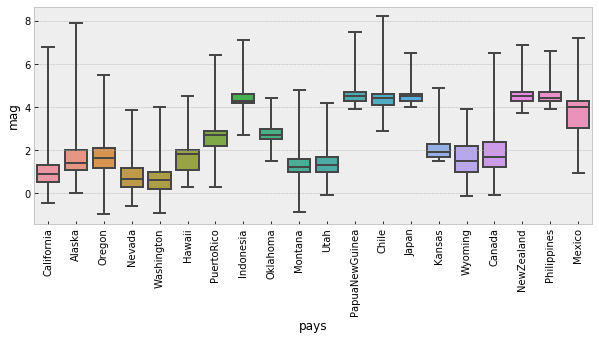

```python
noms = T['pays'].value_counts().head(20).index

pl.figure(figsize=(10,4))
pl.xticks(rotation=90)
seaborn.boxplot(x='pays', y='mag', data=T.query('pays in @noms'),
                whis='range', order=noms)
pl.show()
```

Remarque :

> La force de pandas permet en quelques instants de nous apporter les données.

> Création de cartes des séismes produits en 2014

Retour table des matières

> - Le module geopandas permet de lire le fichier `'countries.json'`.
> - Ce fichier contient les coordonnées gps des frontières de chaque pays du monde

```python
import geopandas as gp

monde = gp.read_file('countries.json')
monde.head()
```

|  | ADMIN | ISO_A3 | geometry |
| --- | --- | --- | --- |
| 0 | Aruba | ABW | POLYGON ((-69.99693762899992 12.57758209800004... |
| 1 | Afghanistan | AFG | POLYGON ((71.04980228700009 38.40866445000009,... |
| 2 | Angola | AGO | (POLYGON ((11.73751945100014 -16.6925779829998... |
| 3 | Anguilla | AIA | (POLYGON ((-63.03766842399995 18.2129580750000... |
| 4 | Albania | ALB | POLYGON ((19.74776574700007 42.57890085900007,... |

Objectif :

> Sélectionnons les seismes de magnitude $\geqslant 1$ et représentons les sur une carte selon sa magnétude.

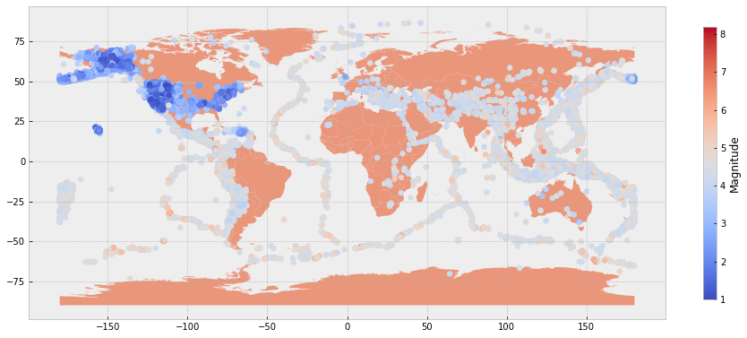

```python
F = T.query('mag >= 1')

fig, ax = pl.subplots(figsize=(15, 8))
monde.plot(color='darksalmon',ax=ax)
pl.scatter(F['longitude'],F['latitude'],c=F['mag'],cmap='coolwarm')

ax_cbar = pl.colorbar(fraction=0.1,pad=0.05,shrink=0.7)
ax_cbar.set_label('Magnitude')
```

```python
len(F)
```

```
82456
```

Objectif :

> Les $82456$ séismes se répartissent le long des plaques tectoniques.

Objectif :

> Créons une carte "dynamique" représentant les $36203$ séismes de `F`.
> - Le module folium permet de représenter des cartes dynamique `'countries.json'`.
> - Nous allons utiliser les cartes proposées par **Open Street Map** et le langage Python afin de générer des cartes personnalisées. Plus exactement, nous allons utiliser une bibliothèque Python nommée `Folium`, pour créer nos propres cartes à partir des cartes proposées par **Open Street Map**

```python
import folium

carte = folium.Map(location=[0,0],tiles='stamenterrain', zoom_start=2)
carte
```

[interactive chart not shown]

```python
from folium.plugins import HeatMap

F = T.query('mag > 2')

GPS = F[['latitude','longitude']].values.tolist()

HeatMap(GPS,radius=4,blur=1,gradient={0.5: 'dark', 0.5: 'blue', 1: 'red'},
        min_opacity=0.4).add_to(carte)
carte
```

[interactive chart not shown]

```python
len(F)
```

```
36203
```

Objectif :

> Représentons par dessus `carte` les sismes de magnétude $\geqslant 6$.

```python
F = T.query('mag >= 6')

from math import sqrt

for i,ligne in F.iterrows():
    folium.CircleMarker(location=(ligne['latitude'],ligne['longitude']),
                        popup=ligne['pays']+'\n'+str(ligne['mag']),
                        color='green',
                        fill_color='yellow',
                        radius=5*sqrt(ligne['mag'])).add_to(carte)
carte
```

[interactive chart not shown]

```python
len(F)
```

```
155
```

> Carte choroplèthe associée au nombre de séismes

Retour table des matières

> Créons la table `E` des effectifs des séismes qui se sont produits

```python
E = T.groupby('pays').count().time.reset_index().query('time >= 10')
E.head()
```

|  | pays | time |
| --- | --- | --- |
| 0 |  | 355 |
| 4 | Afghanistan | 148 |
| 6 | Alaska | 33799 |
| 7 | AlaskaPeninsula | 19 |
| 8 | Albania | 15 |

```python
monde.head()
```

|  | ADMIN | ISO_A3 | geometry |
| --- | --- | --- | --- |
| 0 | Aruba | ABW | POLYGON ((-69.99693762899992 12.57758209800004... |
| 1 | Afghanistan | AFG | POLYGON ((71.04980228700009 38.40866445000009,... |
| 2 | Angola | AGO | (POLYGON ((11.73751945100014 -16.6925779829998... |
| 3 | Anguilla | AIA | (POLYGON ((-63.03766842399995 18.2129580750000... |
| 4 | Albania | ALB | POLYGON ((19.74776574700007 42.57890085900007,... |

Objectif :

> Fusionnons la table `monde` avec la table `E` à partir de :
> - la colonne `ADMIN` de `monde`.
> - et la colonne `pays` de `E`.

```python
M = monde.merge(E,left_on='ADMIN',right_on='pays',how='inner')
M.head()
```

|  | ADMIN | ISO_A3 | geometry | pays | time |
| --- | --- | --- | --- | --- | --- |
| 0 | Afghanistan | AFG | POLYGON ((71.04980228700009 38.40866445000009,... | Afghanistan | 148 |
| 1 | Anguilla | AIA | (POLYGON ((-63.03766842399995 18.2129580750000... | Anguilla | 10 |
| 2 | Albania | ALB | POLYGON ((19.74776574700007 42.57890085900007,... | Albania | 15 |
| 3 | Argentina | ARG | (POLYGON ((-68.65412350199998 -54.886244398999... | Argentina | 196 |
| 4 | Antarctica | ATA | (POLYGON ((-162.4090470039999 -82.896416924999... | Antarctica | 10 |

Objectif :

> Créons la carte des pays du monde en coloriant chacun d'eux avec une couleur selon le nombre de séismes produits dans le pays.

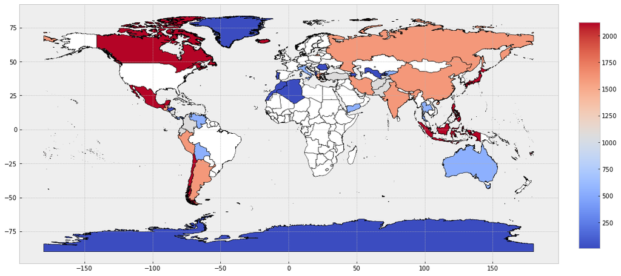

```python
M.crs = {'init' :'epsg:robin'}

fig, ax = pl.subplots(figsize=(16, 13))
monde.plot(ax=ax,edgecolor='black',color='white')
M.plot(ax=ax,column='time', cmap='coolwarm',edgecolor='black',
       alpha=1,scheme='Quantiles')


"""Représentation de la palette de couleur"""
vmin = M['time'].min()
vmax = M['time'].max()
norm=pl.Normalize(vmin=vmin, vmax=vmax)

cax = fig.add_axes([0.93, 0.3, 0.03, 0.4])
sm=pl.cm.ScalarMappable(cmap='coolwarm', norm=norm)
sm._A = []
fig.colorbar(sm, cax=cax,orientation='vertical')
```

Fini ...

Retour au début

```python
from IPython.core.display import HTML
htm = open("style_css.txt").read()
HTML(htm)
```